# `Pedestrian`

Pedestrian count information around Melbourne for 2016

#### Description

This dataset contains hourly counts of pedestrians from 4 sensors around Melbourne: Birrarung Marr, Bourke Street Mall, Flagstaff station, and Spencer St-Collins St (south), recorded from January 1st 2016 at 00:00:00 to December 31st 2016 at 23:00:00.

The data is made free and publicly available from https://data.melbourne.vic.gov.au/Transport-Movement/Pedestrian-volume-updated-monthly-/b2ak-trbp

#### Usage

```
data(pedestrian)
```

#### Format

A tibble with 37,700 rows and 9 variables:

- hourly_counts (integer) the number of pedestrians counted at that sensor at that time
- date_time (POSIXct, POSIXt) The time that the count was taken
- year (integer) Year of record
- month (factor) Month of record as an ordered factor (1 = January, 12 = December)
- month_day (integer) Full day of the month
- week_day (factor) Full day of the week as an ordered factor (1 = Sunday, 7 = Saturday)
- hour (integer) The hour of the day in 24 hour format
- sensor_id (integer) the id of the sensor
- sensor_name (character) the full name of the sensor

#### Source

https://data.melbourne.vic.gov.au/Transport-Movement/Pedestrian-volume-updated-monthly-/ b2ak-trbp

#### Examples

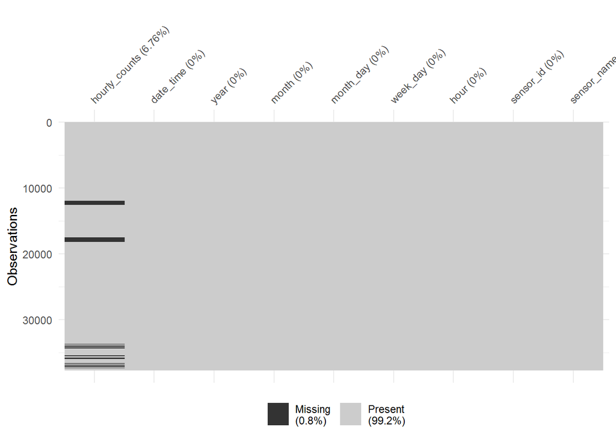

```r
# explore the missingness with vis_miss
library(naniar)
vis_miss(pedestrian)
```

```r
# Look at the missingness in the variables
miss_var_summary(pedestrian)
```

```
## # A tibble: 9 x 3
##   variable      n_miss pct_miss
##   <chr>          <int>    <dbl>
## 1 hourly_counts   2548     6.76
## 2 date_time          0     0
## 3 year               0     0
## 4 month              0     0
## 5 month_day          0     0
## 6 week_day           0     0
## 7 hour               0     0
## 8 sensor_id          0     0
## 9 sensor_name        0     0
```

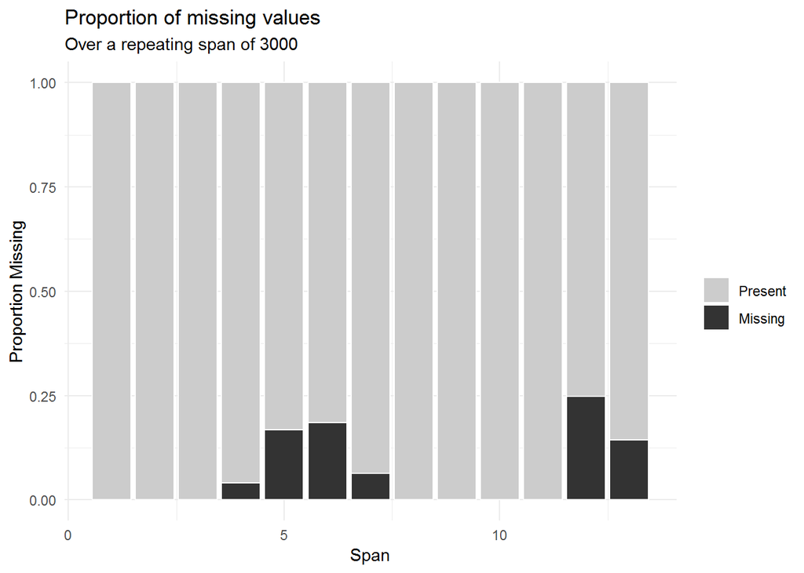

```r
# There is only missingness in hourly_counts
# Look at the missingness over a rolling window
library(ggplot2)
gg_miss_span(pedestrian, hourly_counts, span_every = 3000)
```